# Single-level spatial model

The spatial model predicts each selection from:

- distance to the last item (`rho_delta`),
- direction relative to the last move (`rho_psi`),
- absolute direction (`fourier_coef`).

Here the absolute direction is a Fourier series (`directional_model = "fourier"`): for each harmonic (1, 2 and 4, “Fourier-124”) a $\cos$ and a $\sin$ coefficient (`fourier_coef`), added to each item’s log-weight.

We simulate one person with known parameters, fit the model, and check it recovers them.

Code: `spatial.R`.

```r
# import packages and load our functions
source("../../../../functions/set_up_FoMo.R")
```

```
[1] "set_up_FoMo.R: random seed set to 65 (FOMO_SEED)"
```

```r
# sampler settings (the same in every example; set FOMO_EXAMPLE_ITER for a quick run)
n_iter <- as.integer(Sys.getenv("FOMO_EXAMPLE_ITER", "300"))  # warmup and sampling iterations per chain
n_post_draws <- 50   # posterior draws for posterior predictive simulation
```

## 1 Simulate

$K = 2$ conditions, 25 trials each, on a 9 x 9 grid with a quarter of cells empty.

- `v_type` lets us design stimuli where the items belong to classes (`"cat"`). As we are demonstrating the simplest foraging model that only uses the spatial elements, we set this to `none`.

```r
spec <- list(
  K = 2,
  nrow = 9, ncol = 9,
  prop_missing = 0.25,
  v_type = "none")

stim <- generate_stim(spec, n_trials = 25)
```

The model uses the following parameters, one value of each per condition. Each adds to an item’s log-weight for the next selection:

- $\rho_{\delta}$ (`rho_delta`): distance. An item’s log-weight falls by $\rho_{\delta}\,\delta$, where $\delta$ is its distance from the last selected item, so larger values mean a stronger preference for nearby items ($\rho_{\delta} \ge 0$).
- $\rho_{\psi}$ (`rho_psi`): relative direction. The log-weight falls by $\rho_{\psi}\,\psi$, where $\psi$ is the change of heading from the last move, from 0 (straight on) to 1 (a U-turn). Positive values favour carrying on in the same direction; negative values favour turning back.
- $a_h, b_h$ (`fourier_coef`): absolute direction. The log-weight changes by $\sum_h a_h \cos(h\phi) + b_h \sin(h\phi)$, where $\phi$ is the direction from the last selected item to the item, for harmonics $h = 1, 2, 4$. They’re stored as $(a_1, b_1, a_2, b_2, a_4, b_4)$
  - $h = 1$ gives one preferred direction.
  - $h = 2$ an axis (e.g. left-right over up-down).
  - $h = 4$ the grid’s four directions.

The first selection of a trial has no previous item, so none of these apply to it.

```r
simparams <- list(
  rho_delta_mu = c(0.75, 1.50),
  rho_psi_mu = c(-1, 1),
  # condition one: the four cardinal directions (h4); two: rightwards (h1)
  #                     h1: a, b   h2: a, b   h4: a, b
  fourier_coef_mu = rbind(c(0,   0,   0, 0,    0.8, 0),
                          c(1.5, 0,   0, 0,    0,   0)))
```

The conditions differ in every parameter. Their directional preferences are quite different:

- Condition *one* moves mostly along the four cardinal directions: $a_4 = 0.8$ makes a step right, up, left or down about $e^{1.6} \approx 5$ times as likely as a diagonal one.
- Condition *two* has a strong rightward bias: $a_1 = 1.5$ makes a step right about $e^{3} \approx 20$ times as likely as a step left.

Both are large but plausible under the default priors, which centre every coefficient on 0 with SD 0.35 for $h = 4$ and 0.8 for $h = 1$: about 2 prior SDs each.

We treat our simulation parameters as highly-informative priors. Before running our model, we need to prepare the data:

```r
sl_sim <- prep_stan_list(stim, simparams,
                         directional_model = "fourier")
```

We then pass this list to the *simulate* version of our Stan model:

```r
sim <- sim_fomo(sl_sim, iter = 1, chains = 1)
```

The simulation selects every item, but real foragers often stop early, so `truncate_trials()` drops a few selections from the end of each trial: a Poisson(2) number of them, always keeping at least 10. The dropped items stay on the display, unselected. This allows us to test that our model handles inexhaustive data without problems.

```r
extract_pred(sim, stim) |>
  truncate_trials(lambda = 2, min_keep = 10) -> found

found |> group_by(trial) |>
  summarise(n_found = n()) |>
  head() |>
  knitr::kable()
```

| trial | n_found |
| --- | --- |
| 1 | 58 |
| 2 | 60 |
| 3 | 58 |
| 4 | 59 |
| 5 | 61 |
| 6 | 60 |

By default `plot_trial()` plots one randomly selected trial per condition.

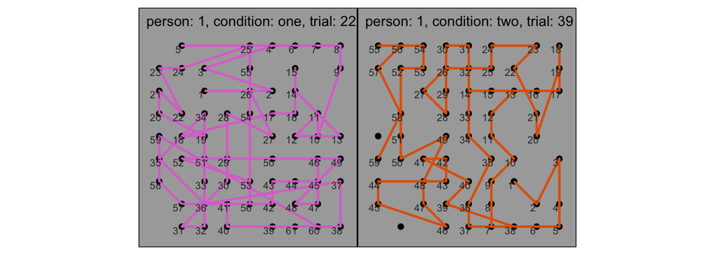

Figure 1: One simulated trial from each condition: items and selection order.

```r
plot_trial(found, stim)
```

We can check our simulated data with some summary plots. Distances should get larger through a trial, as fewer items remain. The direction densities show the simulated preferences filtered through the grid: from any item, the nearest neighbours lie in only eight directions (four along the grid, four diagonal), so the peaks reflect both the model and the layout.

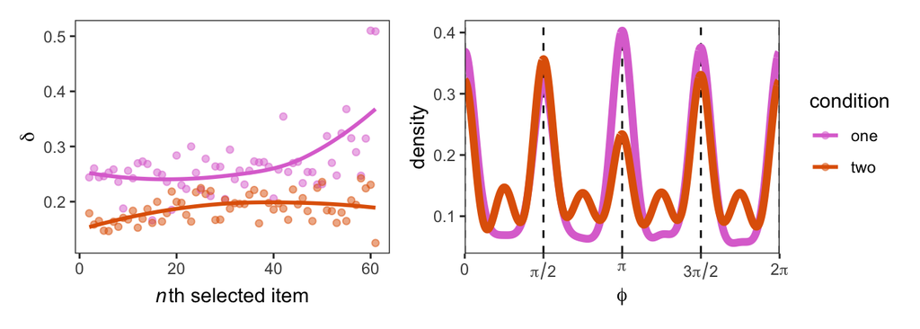

Figure 2: Distance and direction of moves in the simulated data.

```r
plot_steps(found)
```

We can compute a number of trial stats for comparing against the fitted model’s posterior predictions. The number of path self-intersections isn’t computed by default, as it is slow (about 0.06 s per trial, which adds up over posterior draws), so we ask for it here with `which_stats`. Nor is the Lévy-flight exponent (`"levy"`), which is too noisy to compare: two simulations of the same trial barely agree.

```r
trial_stats <- compute_trial_stats(found, which_stats = c("spatial", "intersections"))

head(trial_stats) |> knitr::kable()
```

| trial | condition | person | n_found | best_r | mean_itd | pao | n_intersections | intersection_rate |
| --- | --- | --- | --- | --- | --- | --- | --- | --- |
| 1 | one | 1 | 58 | 0.553 | 0.224 | 55.1 | 35 | 0.603 |
| 2 | one | 1 | 60 | 0.151 | 0.264 | 78.7 | 50 | 0.833 |
| 3 | one | 1 | 58 | 0.469 | 0.259 | 79.7 | 50 | 0.862 |
| 4 | one | 1 | 59 | 0.564 | 0.249 | 85.0 | 49 | 0.831 |
| 5 | one | 1 | 61 | 0.475 | 0.281 | 87.3 | 67 | 1.098 |
| 6 | one | 1 | 60 | 0.332 | 0.252 | 62.9 | 39 | 0.650 |

## 2 Fit

We now fit the single-level (spatial) version of FoMo to our simulated data. Four chains of 500 warmup and 500 sampling iterations.

*Note*: `save_selections = FALSE` by default, because storing a prediction for every selection and draw is too big to read back into R on large datasets. For per-selection accuracy we set it to `TRUE` here; on large datasets, use `predict_fomo()` on a subset of draws instead.

```r
sl <- prep_stan_list(stim, found = found,
                     directional_model = "fourier",
                     save_selections = TRUE)
```

```r
# a fixed seed, so the chains are the same on every run
fit <- fit_fomo(sl, iter = n_iter, chains = 4, seed = FOMO_SEED)
```

## 3 Diagnostics

Posterior medians and 97% HPDIs, the values the data were simulated from (`true`, and whether each is `inside` its HPDI), and convergence (R-hat, ESS). About one in 33 simulation values should fall outside its HPDI by chance. R-hat above 1.01, or a bulk or tail ESS in the low hundreds, means the chains haven’t mixed well enough to trust the tails of the posterior. The summary’s last line names the worst parameter (random effects included); the table colours R-hat and ESS green (good), orange (acceptable) or red (bad). With this few iterations some low ESS values are expected; a real analysis should use more (see `examples/real_data/fit_models/`).

```r
# estimates and convergence, and parameter recovery: are the values used
# to simulate the data inside the posterior's 97% HPDIs?
fomo_summary(fit, sim, cond_labels = levels(stim$condition))
```

**Fixed effects (median and 97% HPDI)**

| parameter | condition | component | lower | median | upper | true | inside | rhat | ess_bulk | ess_tail |
| --- | --- | --- | --- | --- | --- | --- | --- | --- | --- | --- |
| rho_delta | one |  | 0.72 | 0.76 | 0.81 | 0.75 | TRUE | 1.00 | 4008 | 1483 |
| rho_delta | two |  | 1.50 | 1.60 | 1.70 | 1.51 | TRUE | 1.00 | 3714 | 1411 |
| rho_psi | one |  | -1.01 | -0.79 | -0.56 | -1.00 | TRUE | 1.00 | 5468 | 1618 |
| rho_psi | two |  | 0.82 | 1.13 | 1.45 | 1.02 | TRUE | 1.01 | 3588 | 1503 |
| fourier_coef | one | h1 cos | -0.05 | 0.04 | 0.13 | 0.00 | TRUE | 1.00 | 4693 | 1698 |
| fourier_coef | two | h1 cos | 1.44 | 1.58 | 1.73 | 1.51 | TRUE | 1.00 | 3853 | 1814 |
| fourier_coef | one | h1 sin | -0.08 | 0.01 | 0.11 | 0.01 | TRUE | 1.01 | 5472 | 1519 |
| fourier_coef | two | h1 sin | -0.11 | 0.00 | 0.10 | 0.02 | TRUE | 1.00 | 3874 | 1648 |
| fourier_coef | one | h2 cos | -0.03 | 0.05 | 0.12 | 0.01 | TRUE | 1.01 | 4592 | 1441 |
| fourier_coef | two | h2 cos | -0.12 | -0.02 | 0.08 | 0.00 | TRUE | 1.00 | 4656 | 1412 |
| fourier_coef | one | h2 sin | -0.08 | 0.06 | 0.18 | 0.02 | TRUE | 1.00 | 5285 | 1619 |
| fourier_coef | two | h2 sin | -0.11 | 0.01 | 0.13 | 0.00 | TRUE | 1.00 | 4774 | 1465 |
| fourier_coef | one | h4 cos | 0.71 | 0.80 | 0.90 | 0.83 | TRUE | 1.01 | 3969 | 1643 |
| fourier_coef | two | h4 cos | -0.14 | -0.05 | 0.03 | -0.01 | TRUE | 1.01 | 4508 | 1685 |
| fourier_coef | one | h4 sin | -0.09 | 0.04 | 0.18 | 0.00 | TRUE | 1.00 | 5934 | 1476 |
| fourier_coef | two | h4 sin | -0.16 | 0.02 | 0.20 | 0.02 | TRUE | 1.01 | 4041 | 1298 |

Recovery: 16 of 16 (100%) simulation values inside the 97% HPDI; about 97% expected by chance.

Convergence (all parameters): largest R-hat 1.010 (fourier_coef[2,6]); smallest bulk ESS 3588 (rho_psi[2]), tail ESS 1298 (fourier_coef[2,6]); 0 divergent transitions.

Rank plots of the five worst-mixing parameters, judged by R-hat and ESS together. Each histogram shows where one chain’s draws rank among all the draws: if the chains have mixed well, every chain’s histogram is roughly flat and they overlap. A chain sitting above or below the others has spent too long in one part of the posterior.

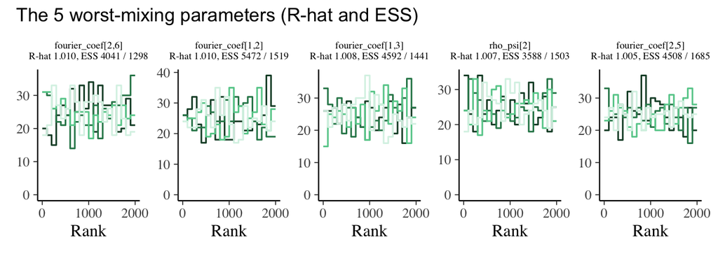

Figure 3: Rank plots of the five worst-mixing parameters, coloured green (good), orange (acceptable) or red (bad) by their R-hat and ESS.

```r
plot_post_traces(fit)
```

`log_lik` is one value per trial, so loo leaves out a whole trial at a time. A Pareto k above 0.7 marks a trial the fit leans on heavily, whose loo estimate is unreliable. A few are common with this few trials; many would mean loo comparisons need checking with K-fold cross-validation. `check_high_pareto_k()` lists those trials, worst first, with the person each belongs to (`z`).

```r
loo_result <- fit$loo()
loo_result
```

```
Computed from 2000 by 50 log-likelihood matrix.

         Estimate    SE
elpd_loo  -4985.1 174.6
p_loo        15.7   1.0
looic      9970.3 349.2
------
MCSE of elpd_loo is 0.1.
MCSE and ESS estimates assume MCMC draws (r_eff in [1.0, 2.1]).

All Pareto k estimates are good (k < 0.7).
See help('pareto-k-diagnostic') for details.
```

```r
# the trials with a high Pareto k, worst first
check_high_pareto_k(loo_result, sl)
```

```
# A tibble: 0 × 3
# ℹ 3 variables: trial_idx <int>, z <int>, k <dbl>
```

## 4 Posterior

### 4.1 Posterior densities

Where a posterior sits well inside its prior band, the data rather than the prior set the estimate. A posterior pressed against the edge of its band means the prior is doing some of the work.

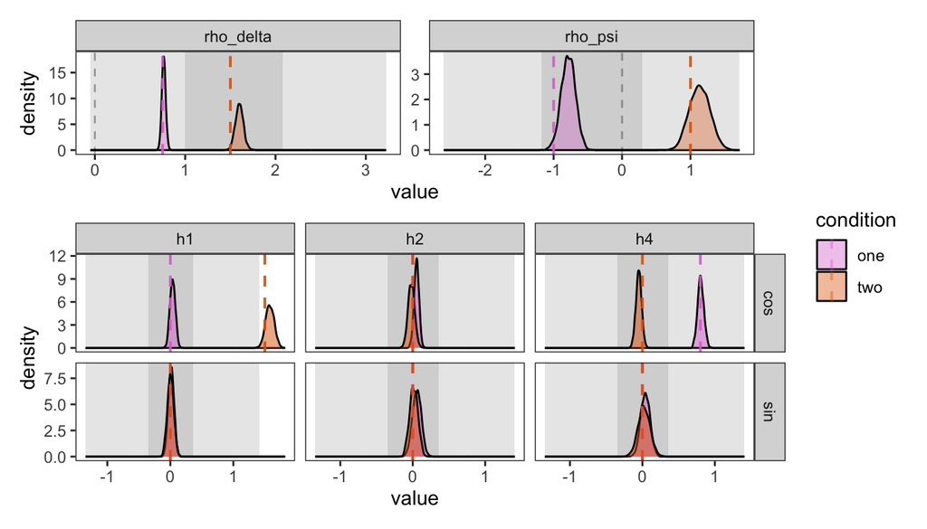

Figure 4: Posterior densities by condition. Grey bands: prior HPDIs; dashed lines: simulation values.

```r
post <- extract_post(fit, found, stim)
plot_post(post, groundtruth = simparams)
```

The same parameters, shown as what each does to an item’s selection weight: the negative exponential in distance, the same in the turn from the previous step (rho_psi), and the directional curve.

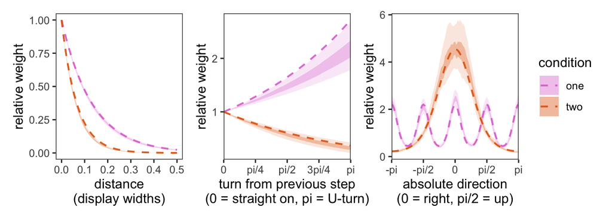

Figure 5: Relative selection weight against distance, turn angle and direction: 53% and 97% HPDIs; dashed: simulation values.

```r
# the same parameters as what they do to an item's selection weight
plot_post_spatial(post, groundtruth = simparams, show = "weights")
```

### 4.2 Accuracy

- Deterministic accuracy: how often the item the model judges most likely is the one selected.
- Probability of the chosen item: the probability the model gave the item that was selected, averaged over selections; it credits the model for being nearly right, not only for top picks.
- Chance (1 / items left) rises through a trial as fewer items remain.
- The nearest-neighbour baseline always picks the closest remaining item, so the gap above it is what the model adds to proximity alone.

*Note*: this is in-sample accuracy, which overestimates out-of-sample accuracy.

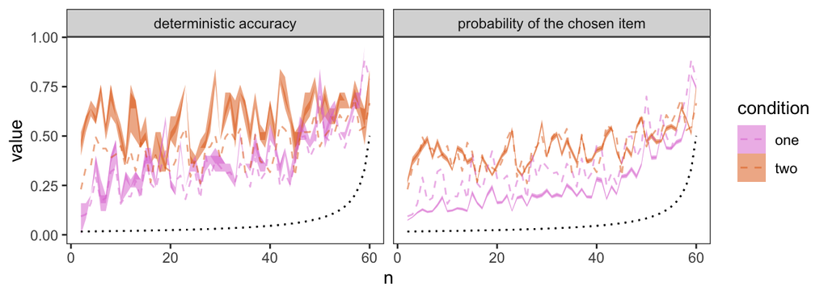

Figure 6: Accuracy of the model’s predictions at each selection, with chance and nearest-neighbour baselines.

```r
plot_post_accuracy(post$acc, stim, found)
```

## 5 Posterior predictive check

The model doesn’t predict when a trial stops, so each simulated trial keeps as many selections as the data have.

```r
sim_post <- sim_fomo(sl, fit, iter = n_post_draws)

extract_pred(sim_post, stim) |>
  semi_join(found, by = c("trial", "n")) -> found_post
```

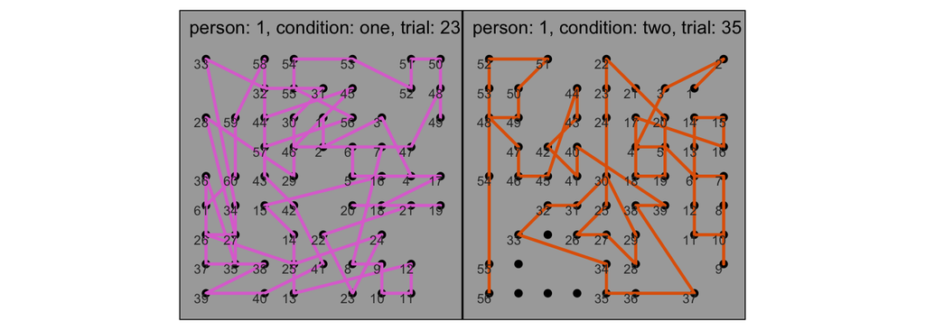

Figure 7: One trial per condition, simulated from the fitted model.

```r
plot_trial(found_post, stim)
```

Finally, we compare per-trial foraging statistics between the training data and data simulated from the fitted posterior. As none of the trial statistics below are model parameters, reproducing them tests whether the fitted model captures aspects of the behaviour it was not fitted to directly.

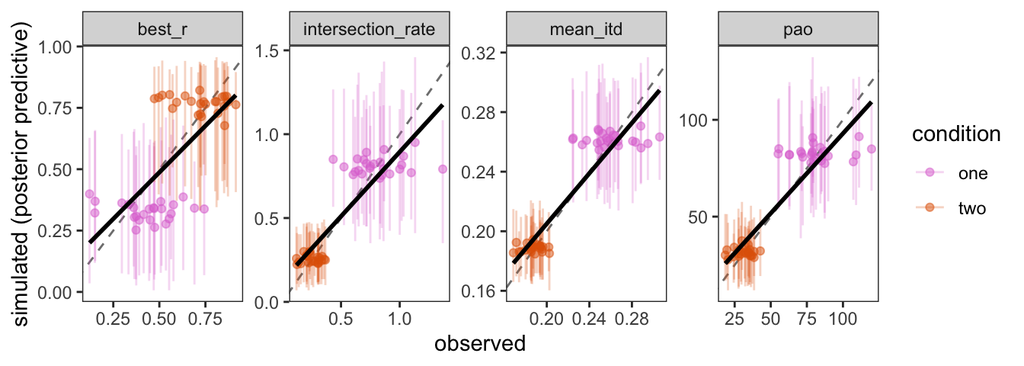

Figure 8: Trial statistics for the fitted data (x) and data simulated from the posterior (y). Points near the diagonal mean the model reproduces them.

```r
sim_stats <- compute_trial_stats(found_post, which_stats = c("spatial", "intersections"))
plot_trial_stats(trial_stats, sim_stats)
```